# chapter3

Hsiang-Leng, Wang

2019/11/22

# MOOC Introduction to Open Data Science 2019: Homework3

## Step1. Check the data

#### Read the joined student alcohol consumption data as alc dataset

```r
alc <- read.table("http://s3.amazonaws.com/assets.datacamp.com/production/course_2218/datasets/alc.txt", sep=",", header=TRUE)
```

#### Summary the alc dataset

```r
str(alc)
```

```
## 'data.frame':    382 obs. of  35 variables:
##  $ school    : Factor w/ 2 levels "GP","MS": 1 1 1 1 1 1 1 1 1 1 ...
##  $ sex       : Factor w/ 2 levels "F","M": 1 1 1 1 1 2 2 1 2 2 ...
##  $ age       : int  18 17 15 15 16 16 16 17 15 15 ...
##  $ address   : Factor w/ 2 levels "R","U": 2 2 2 2 2 2 2 2 2 2 ...
##  $ famsize   : Factor w/ 2 levels "GT3","LE3": 1 1 2 1 1 2 2 1 2 1 ...
##  $ Pstatus   : Factor w/ 2 levels "A","T": 1 2 2 2 2 2 2 1 1 2 ...
##  $ Medu      : int  4 1 1 4 3 4 2 4 3 3 ...
##  $ Fedu      : int  4 1 1 2 3 3 2 4 2 4 ...
##  $ Mjob      : Factor w/ 5 levels "at_home","health",..: 1 1 1 2 3 4 3 3 4 3 ...
##  $ Fjob      : Factor w/ 5 levels "at_home","health",..: 5 3 3 4 3 3 3 5 3 3 ...
##  $ reason    : Factor w/ 4 levels "course","home",..: 1 1 3 2 2 4 2 2 2 2 ...
##  $ nursery   : Factor w/ 2 levels "no","yes": 2 1 2 2 2 2 2 2 2 2 ...
##  $ internet  : Factor w/ 2 levels "no","yes": 1 2 2 2 1 2 2 1 2 2 ...
##  $ guardian  : Factor w/ 3 levels "father","mother",..: 2 1 2 2 1 2 2 2 2 2 ...
```

[output cut: 21 more lines]

The dataset alc includes 35 varibles with 382 rows. The alc_use is the average of column Dalc and Walc (weekday and weekend alcohol consumption). If the average alcohol consumption is higher than 2, it is regarded as high alcohol usage student which is shown in column ‘high_use’ as TRUE.

#### Choose four interesting variables in alc dataset

Personally, I think alcohol consumption is related to a person’s relationship with family members, higher alcohol concumption may caused by bad relationship, so I select #24 famrel as one onf the analysis target. In addition, in my opinion, if a student tends to have a promising future, he/she may focus on study more rather than be absent in class too often, so I select #14 studytime and #30 absences as the interesing variables. Last, I am interested in if the score is related to alcohol consumption, so I choose #32 G3 as the fourth variable.

> - #14 studytime - weekly study time (numeric: 1 - <2 hours, 2 - 2 to 5 hours, 3 - 5 to 10 hours, or 4 - >10 hours)
> - #24 famrel - quality of family relationships (numeric: from 1 - very bad to 5 - excellent)
> - #30 absences - number of school absences (numeric: from 0 to 93)
> - #32 G3 - final grade (numeric: from 0 to 20, output target)

```r
library(magrittr) # needs to be run every time you start R and want to use %>%
library(dplyr)
alc_4 <- alc %>% select(16, 24, 30, 33, 34, 35)
head(alc_4, n=10)
```

```
##    studytime famrel absences G3 alc_use high_use
## 1          2      4        6  6     1.0    FALSE
## 2          2      5        4  6     1.0    FALSE
## 3          2      4       10 10     2.5     TRUE
## 4          3      3        2 15     1.0    FALSE
## 5          2      4        4 10     1.5    FALSE
## 6          2      5       10 15     1.5    FALSE
## 7          2      4        0 11     1.0    FALSE
## 8          2      4        6  6     1.0    FALSE
## 9          2      4        0 19     1.0    FALSE
## 10         2      5        0 15     1.0    FALSE
```

#### Graphically explore: a) cross-tabulations b) scatter plots

##### a) cross-tabulations

high_use vs studytime

```r
alc_4.v1 <- table(alc$high_use, alc$studytime)
round(prop.table(alc_4.v1,1), 2)
```

```
##
##            1    2    3    4
##   FALSE 0.22 0.49 0.20 0.09
##   TRUE  0.38 0.51 0.07 0.04
```

high_use vs famrel

```r
alc_4.v2 <- table(alc$high_use, alc$famrel)
round(prop.table(alc_4.v2,1), 2)
```

```
##
##            1    2    3    4    5
##   FALSE 0.03 0.03 0.15 0.49 0.31
##   TRUE  0.02 0.08 0.23 0.46 0.21
```

high_use vs absences

```r
alc_4.v3 <- table(alc$high_use, alc$absences)
round(prop.table(alc_4.v3,1), 2)
```

```
##
##            0    1    2    3    4    5    6    7    8    9   10   11   12   13
##   FALSE 0.35 0.01 0.20 0.01 0.13 0.01 0.07 0.02 0.05 0.01 0.04 0.00 0.02 0.00
##   TRUE  0.20 0.01 0.12 0.04 0.13 0.00 0.10 0.02 0.07 0.00 0.04 0.01 0.04 0.03
##
##           14   15   16   17   18   19   20   21   22   23   24   25   26   28
##   FALSE 0.03 0.00 0.01 0.00 0.01 0.00 0.00 0.00 0.00 0.00 0.00 0.00 0.00 0.00
##   TRUE  0.04 0.02 0.04 0.01 0.02 0.01 0.01 0.00 0.03 0.00 0.01 0.00 0.00 0.01
##
##           30   54   56   75
##   FALSE 0.00 0.00 0.00 0.00
##   TRUE  0.01 0.01 0.01 0.00
```

high_use vs G3

```r
alc_4.v4 <- table(alc$high_use, alc$G3)
round(prop.table(alc_4.v4,1), 2)
```

```
##
##            0    4    5    6    7    8    9   10   11   12   13   14   15   16
##   FALSE 0.12 0.00 0.01 0.05 0.02 0.06 0.07 0.13 0.11 0.07 0.05 0.09 0.10 0.05
##   TRUE  0.05 0.01 0.04 0.02 0.02 0.14 0.08 0.20 0.11 0.10 0.11 0.03 0.04 0.04
##
##           17   18   19   20
##   FALSE 0.01 0.04 0.02 0.00
##   TRUE  0.02 0.02 0.00 0.00
```

##### b) scatter plots

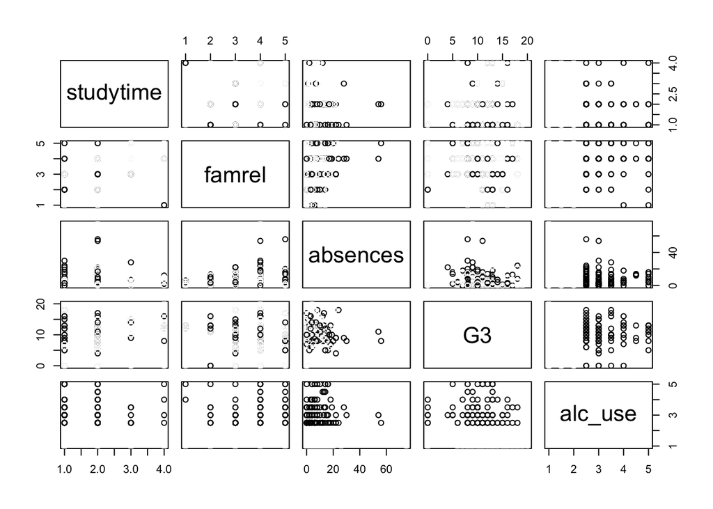

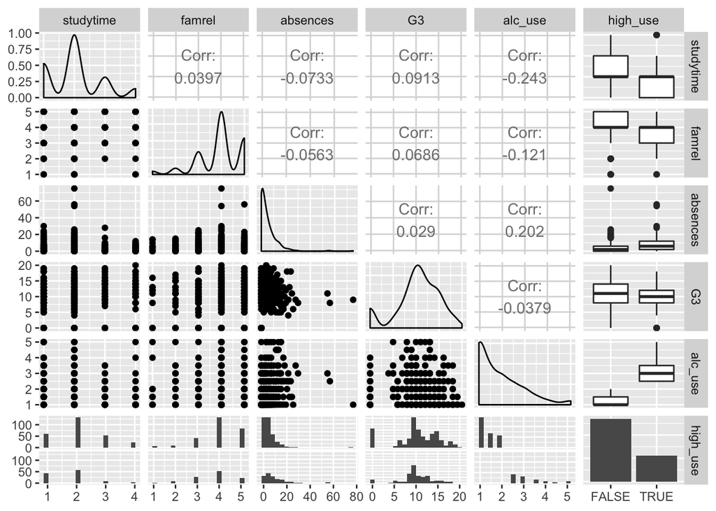